# 3. Results Analysis and Visualization

##### 5.3.1.1.2 E Max

🔍 Zoom In for Details

💾 Download Table

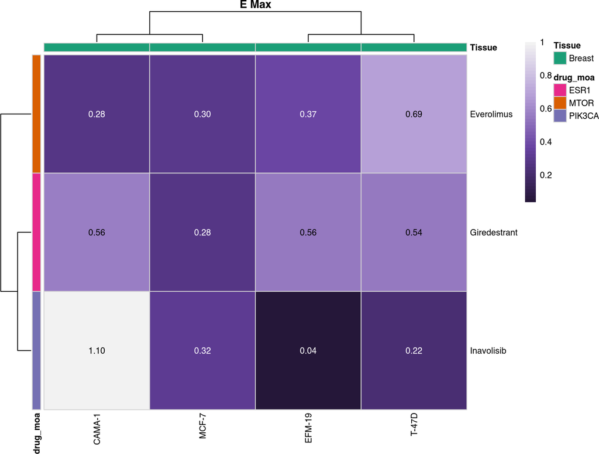

##### 5.3.1.1.3 RV Mean

🔍 Zoom In for Details

💾 Download Table

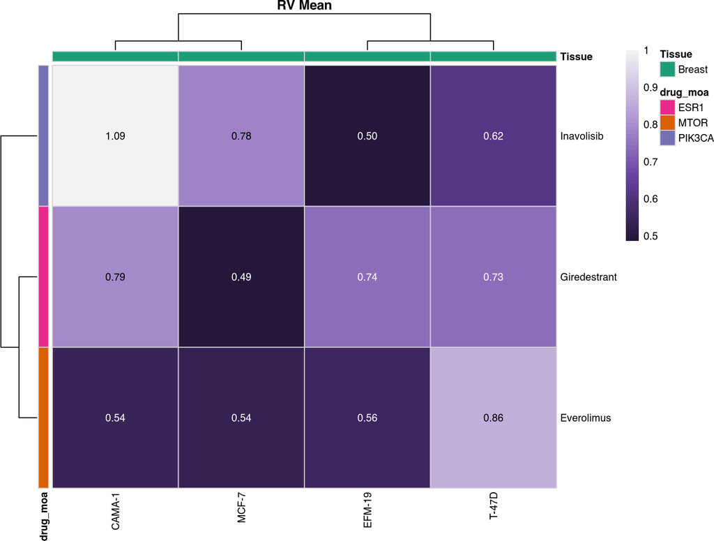

##### 5.3.1.1.4 RV AOC

🔍 Zoom In for Details

💾 Download Table

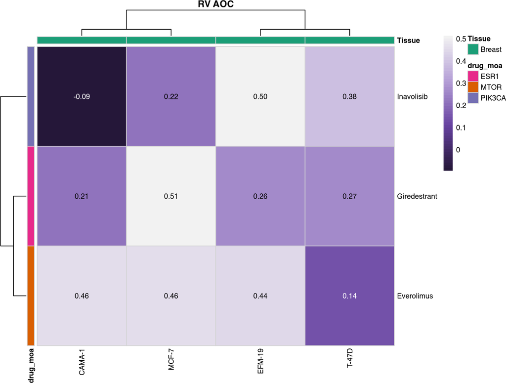

##### 5.3.1.1.5 RV AOC within set range

🔍 Zoom In for Details

💾 Download Table

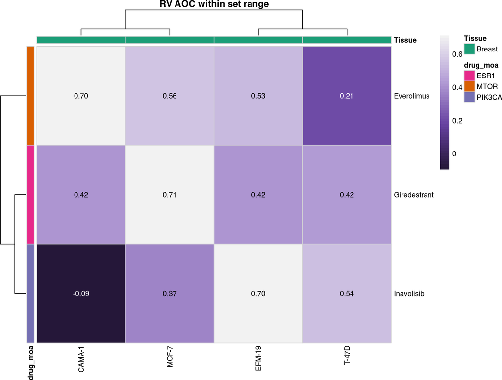

#### 5.3.1.2 GR Value

##### 5.3.1.2.1 log10(GR50)

🔍 Zoom In for Details

💾 Download Table

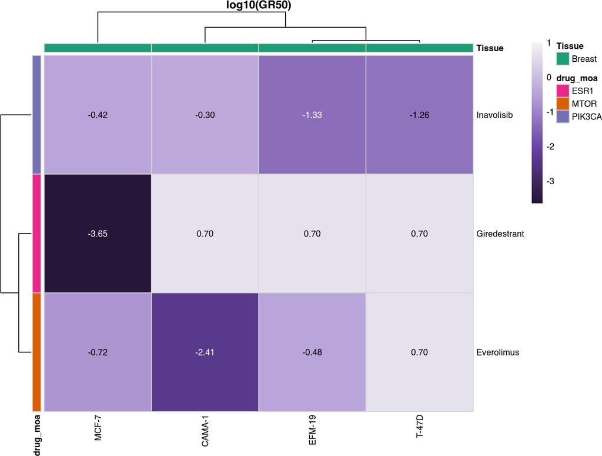

##### 5.3.1.2.2 GR Max

🔍 Zoom In for Details

💾 Download Table

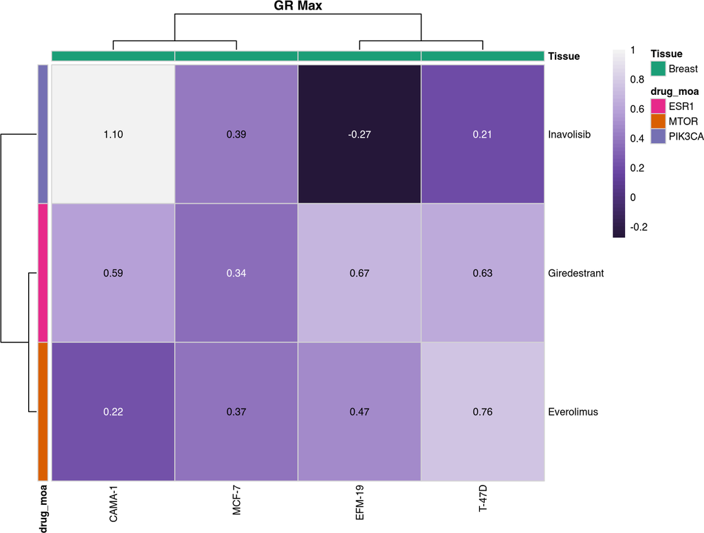

##### 5.3.1.2.3 GR Mean

🔍 Zoom In for Details

💾 Download Table

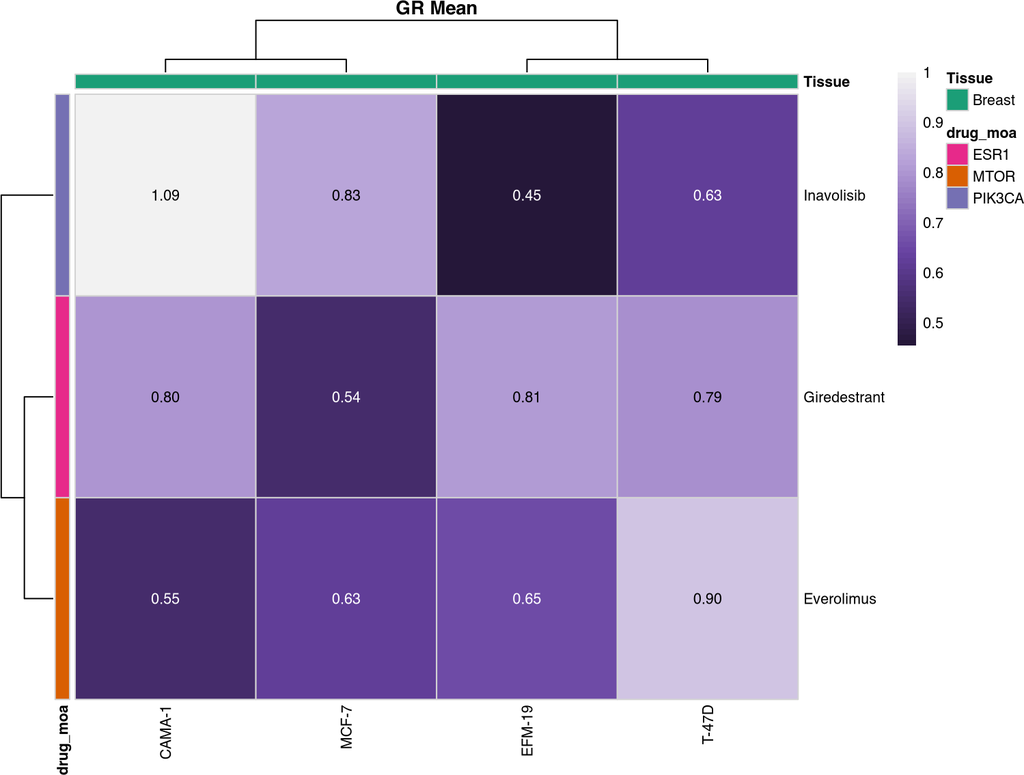

##### 5.3.1.2.4 GR AOC

🔍 Zoom In for Details

💾 Download Table

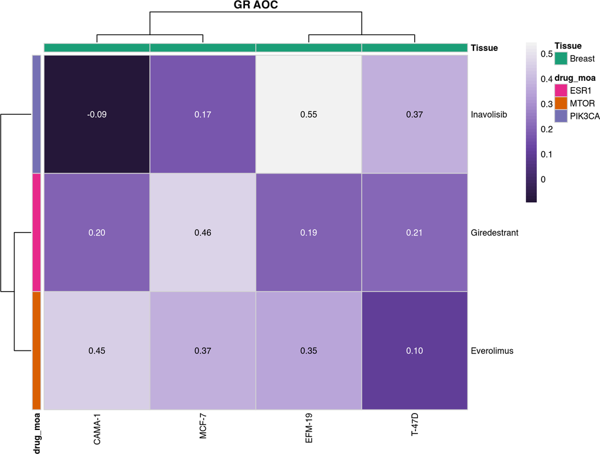

##### 5.3.1.2.5 GR AOC within set range

🔍 Zoom In for Details

💾 Download Table

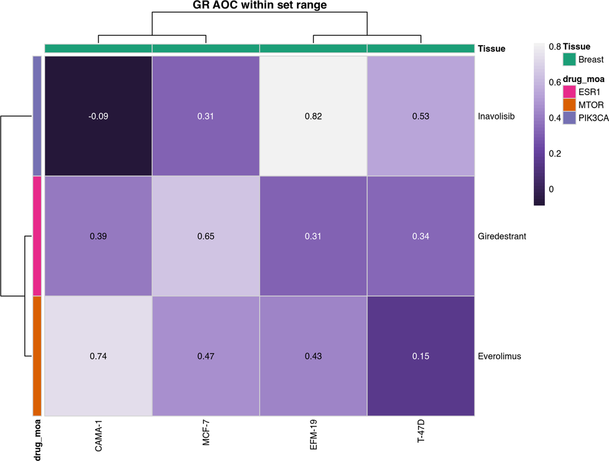

### 5.3.2 Boxplots by Cell Lines

The boxplots show the distribution of a given metric, grouped by cell line.

**What to look for:** When grouped by cell line, you can identify cell lines that are, on average, more sensitive or resistant to the entire panel of drugs.

```r
# metrics
metrics <- data.table(
  expand.grid(normalization_type = c("GR", "RV"),
              metric = c("xc50", "x_max", "x_mean", "x_AOC", "x_AOC_range"),
              stringsAsFactors = FALSE))

ls_plt_RV <- pmap(metrics[normalization_type == "RV", ],
                  plot_boxplot_metric_sa_by_CLs,
                  dt_metrics = response_metrics_sa_capped,
                  colored_pts_flag = TRUE)
names(ls_plt_RV) <- unlist(pmap(metrics[normalization_type == "RV", ], get_hm_title))
```

```r
ls_plt_GR <- pmap(metrics[normalization_type == "GR", ],
                  plot_boxplot_metric_sa_by_CLs,
                  dt_metrics = response_metrics_sa_capped,
                  colored_pts_flag = TRUE)
names(ls_plt_GR) <- unlist(pmap(metrics[normalization_type == "GR", ], get_hm_title))
```

#### 5.3.2.1 Relative Viability

##### 5.3.2.1.1 log10(IC50)

🔍 Zoom In for Details

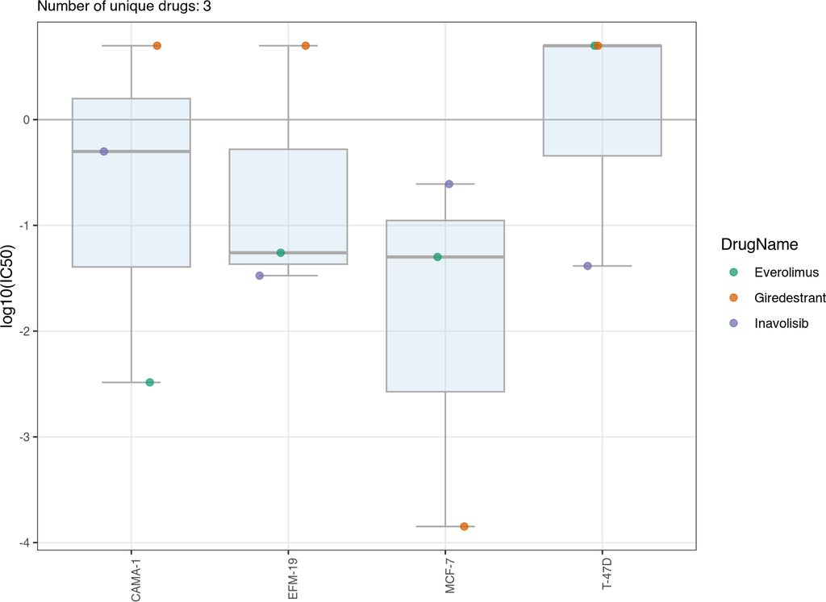

##### 5.3.2.1.2 E Max

🔍 Zoom In for Details

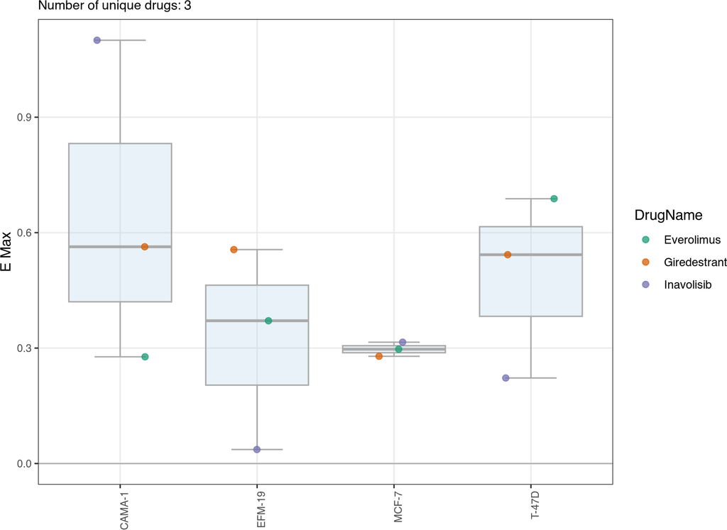

##### 5.3.2.1.3 RV Mean

🔍 Zoom In for Details

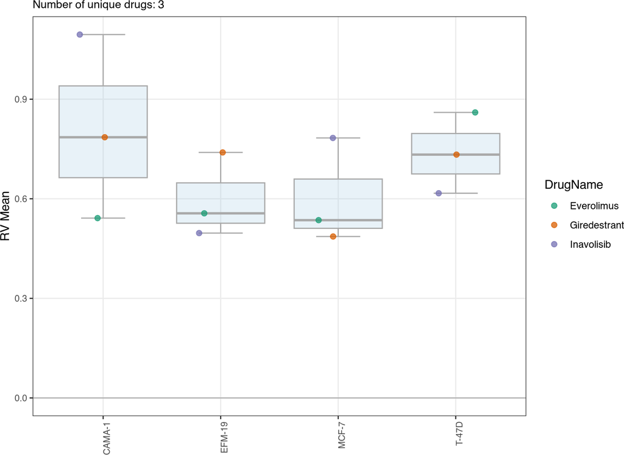

##### 5.3.2.1.4 RV AOC

🔍 Zoom In for Details

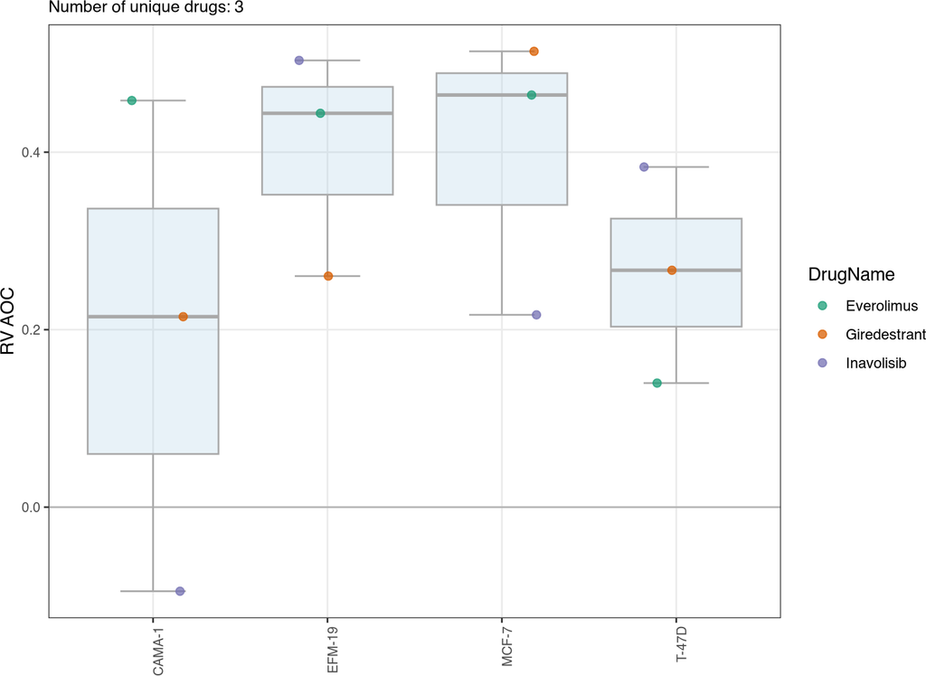

##### 5.3.2.1.5 RV AOC within set range

🔍 Zoom In for Details

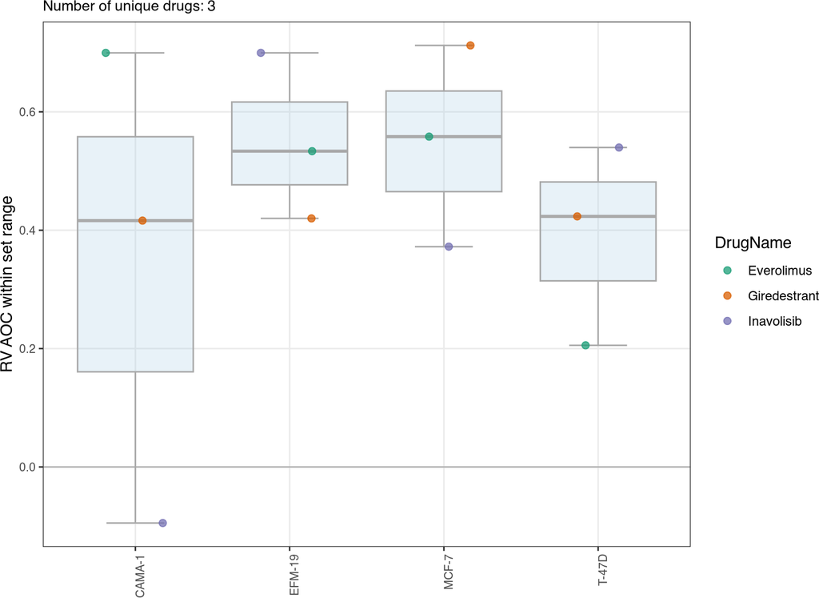

#### 5.3.2.2 GR Value

##### 5.3.2.2.1 log10(GR50)

🔍 Zoom In for Details

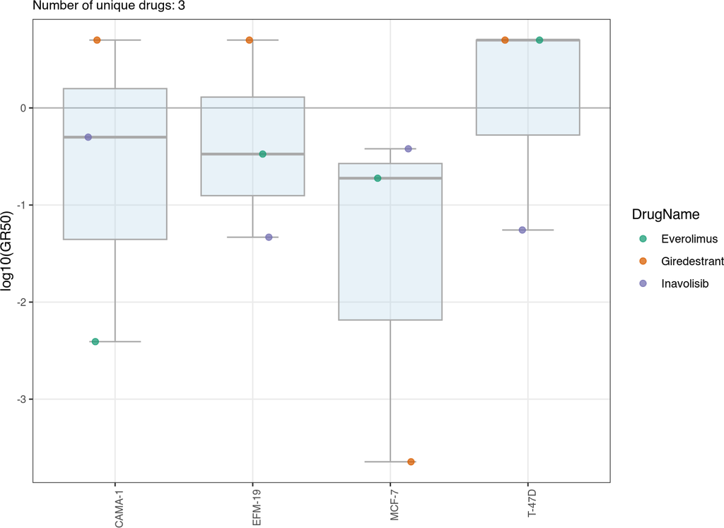

##### 5.3.2.2.2 GR Max

🔍 Zoom In for Details

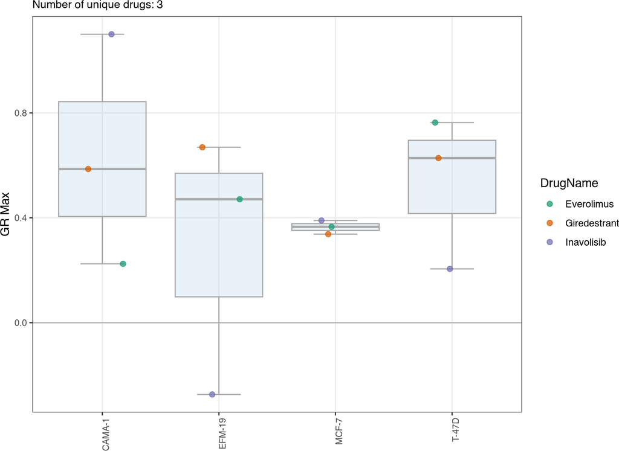

##### 5.3.2.2.3 GR Mean

🔍 Zoom In for Details

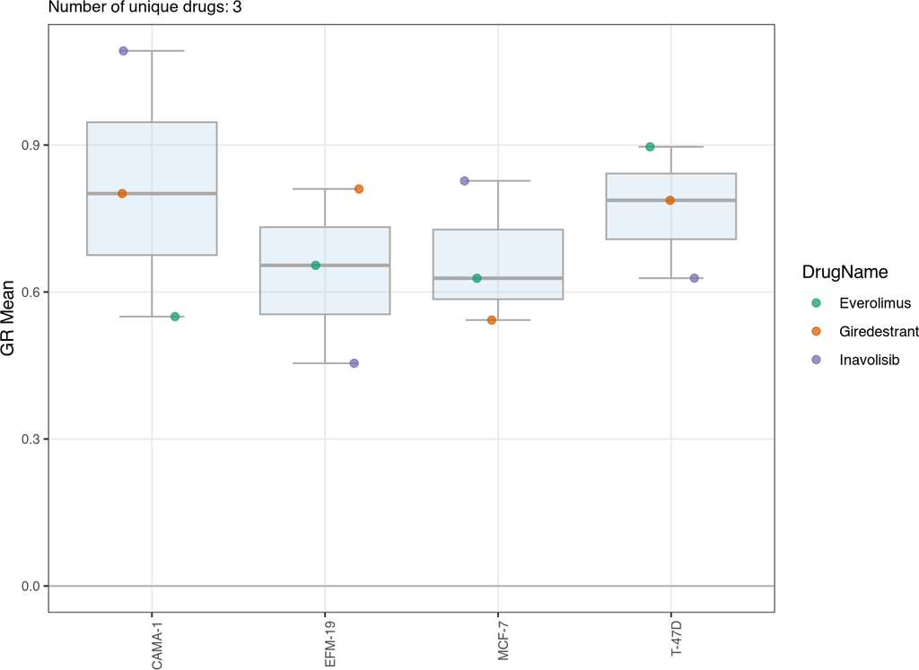

##### 5.3.2.2.4 GR AOC

🔍 Zoom In for Details

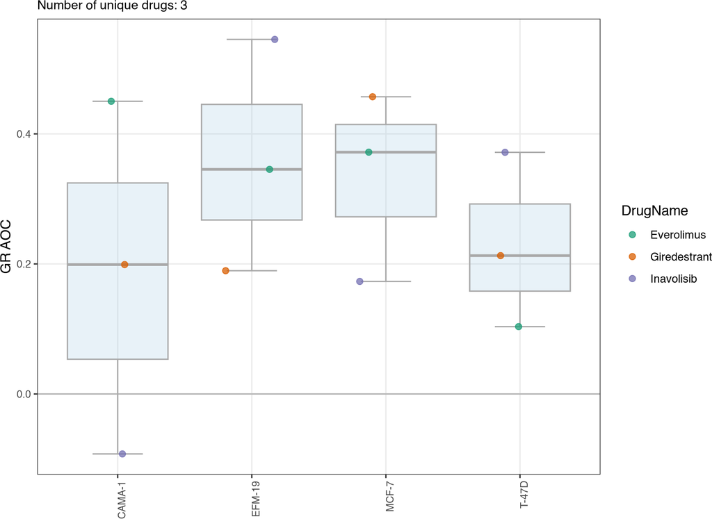

##### 5.3.2.2.5 GR AOC within set range

🔍 Zoom In for Details

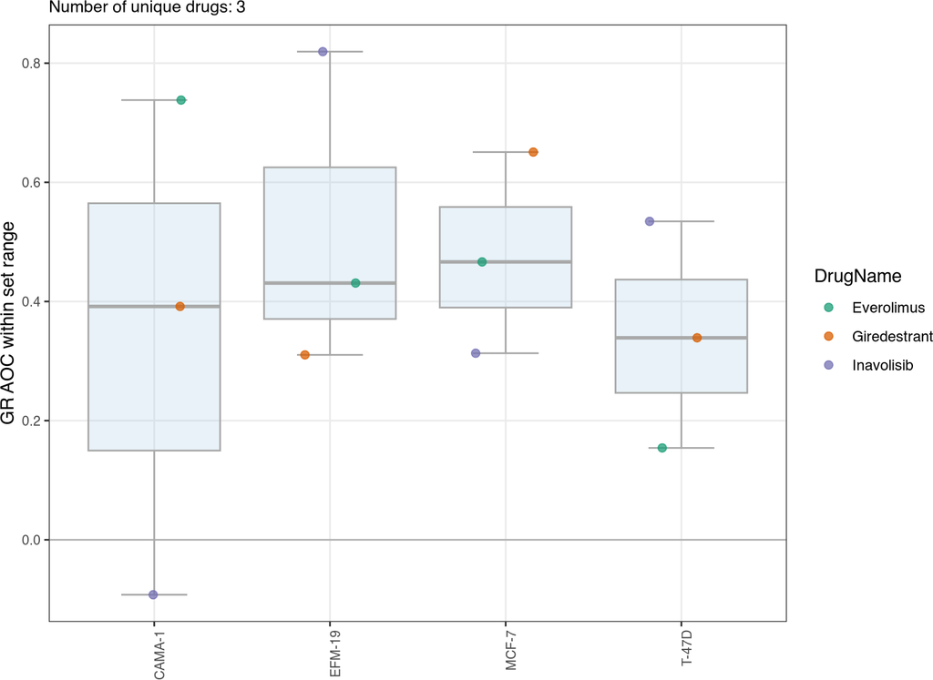

### 5.3.3 Boxplots by Drugs

These boxplots show the distribution of a given metric, grouped by drug.

**What to look for:** You can identify drugs that are, on average, more potent or effective across all cell lines.

```r
metrics <- data.table(
  expand.grid(normalization_type = c("GR", "RV"),
              metric = c("xc50", "x_max", "x_mean", "x_AOC", "x_AOC_range"),
              stringsAsFactors = FALSE))

ls_plt_RV <- pmap(metrics[normalization_type == "RV", ],
                  plot_boxplot_metric_sa_by_drugs,
                  dt_metrics = response_metrics_sa_capped,
                  colored_pts_flag = TRUE)
names(ls_plt_RV) <- unlist(pmap(metrics[normalization_type == "RV", ], get_hm_title))
```

```r
ls_plt_GR <- pmap(metrics[normalization_type == "GR", ],
                  plot_boxplot_metric_sa_by_drugs,
                  dt_metrics = response_metrics_sa_capped,
                  colored_pts_flag = TRUE)
names(ls_plt_GR) <- unlist(pmap(metrics[normalization_type == "GR", ], get_hm_title))
```

#### 5.3.3.1 Relative Viability

##### 5.3.3.1.1 log10(IC50)

🔍 Zoom In for Details

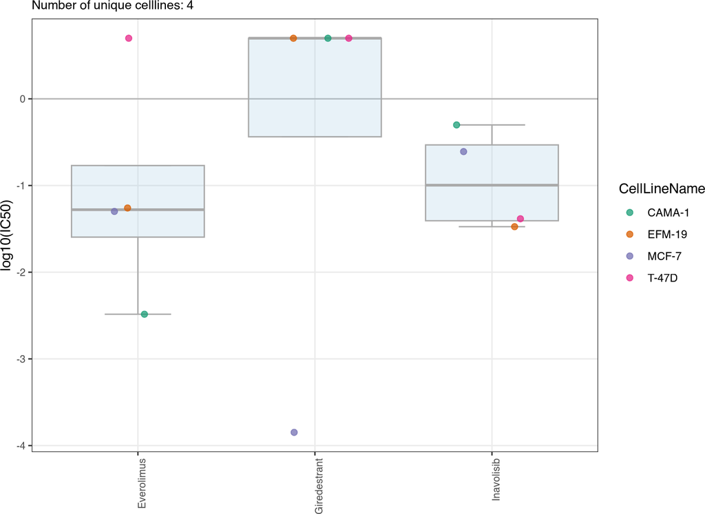

##### 5.3.3.1.2 E Max

🔍 Zoom In for Details

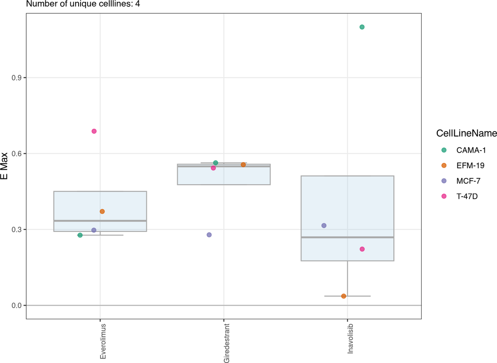

##### 5.3.3.1.3 RV Mean

🔍 Zoom In for Details

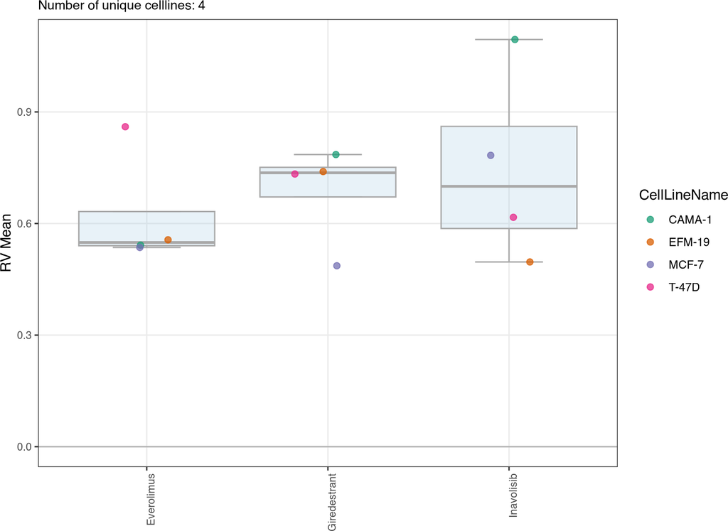

##### 5.3.3.1.4 RV AOC

🔍 Zoom In for Details

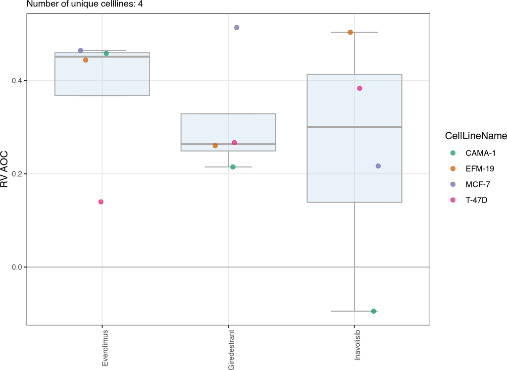

##### 5.3.3.1.5 RV AOC within set range

🔍 Zoom In for Details

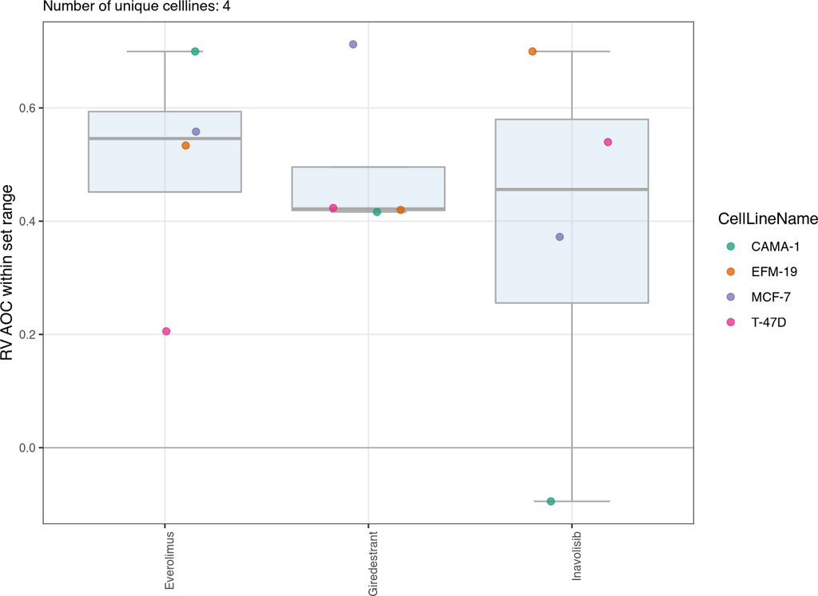

#### 5.3.3.2 GR Value

##### 5.3.3.2.1 log10(GR50)

🔍 Zoom In for Details

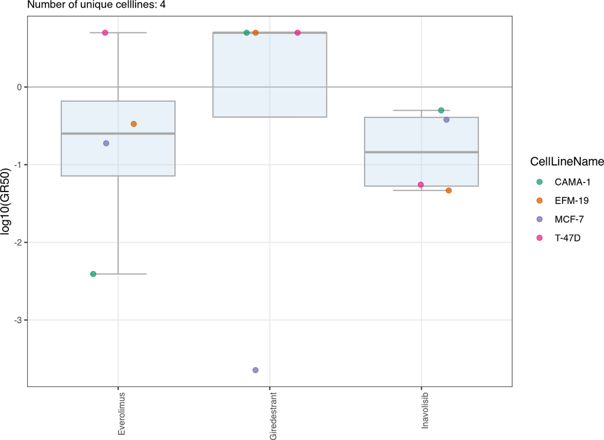

##### 5.3.3.2.2 GR Max

🔍 Zoom In for Details

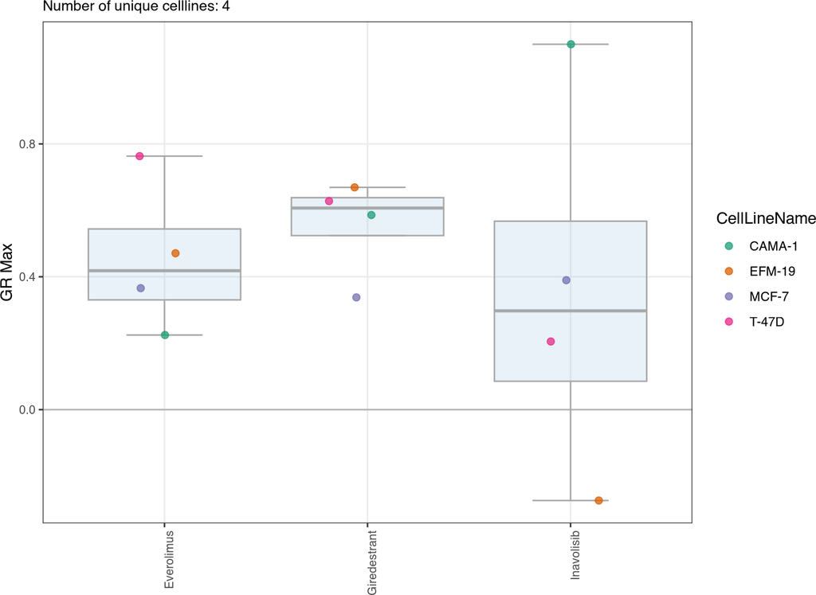

##### 5.3.3.2.3 GR Mean

🔍 Zoom In for Details

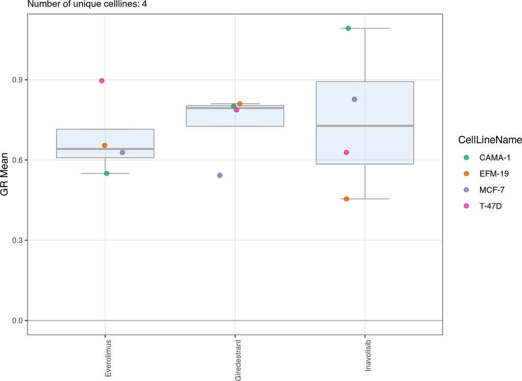

##### 5.3.3.2.4 GR AOC

🔍 Zoom In for Details

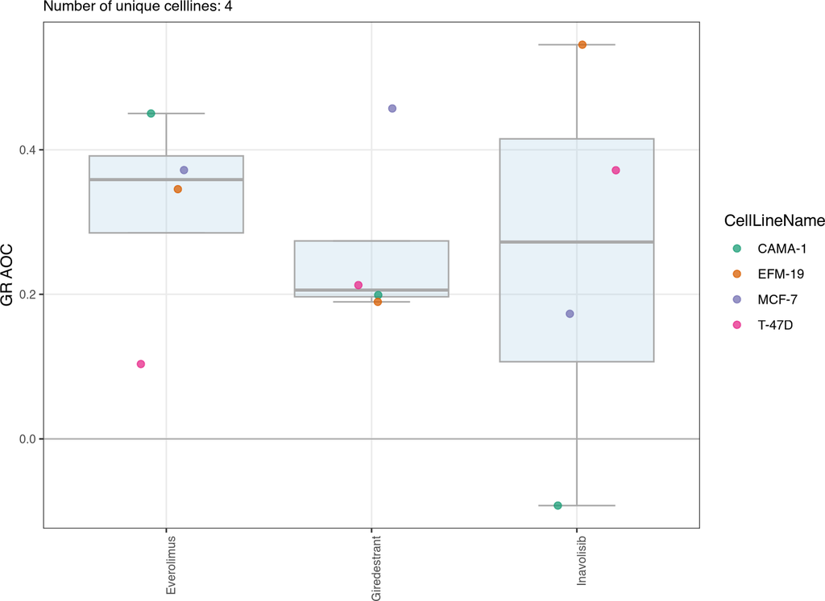

##### 5.3.3.2.5 GR AOC within set range

🔍 Zoom In for Details

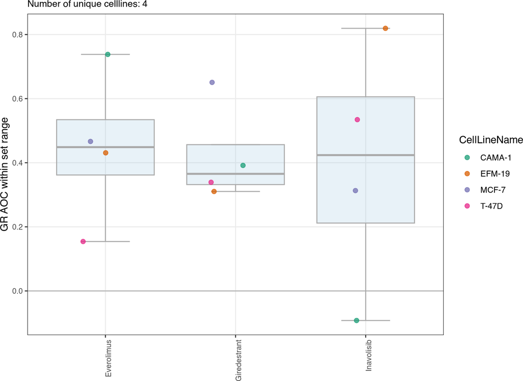

### 5.3.4 Boxplots by Tissue

The boxplots show the distribution of a given metric, grouped by tissue.

**What to look for:** When grouped by tissue, you can identify tissues that are, on average, more sensitive or resistant to the entire panel of drugs.

```r
drug_name_vec <-
  list(selection_name = sort(unique(response_metrics_sa_capped[["DrugName"]])))

ls_names <-
  vapply(drug_name_vec$selection_name, function(i) escape_special_characters(i),
         FUN.VALUE = character(1), USE.NAMES = FALSE)

metrics <- data.table(
  expand.grid(normalization_type = c("GR", "RV"),
              metric = c("xc50", "x_max", "x_mean", "x_AOC", "x_AOC_range"),
              stringsAsFactors = FALSE),
  named_n_mode = rep(c("bottom", "bottom", "bottom", "top", "top"), each = 2))
```

```r
metrics_RV <- metrics[normalization_type == "RV", ]
ls_plt_RV <- lapply(seq_len(NROW(metrics_RV)), function(i) {
  ls_ <- pmap(drug_name_vec,
              plot_boxplot_metric_sa_by_grp,
              dt_metrics = response_metrics_sa_capped,
              selection_var = "DrugName",
              group_var = "Tissue",
              normalization_type = "RV",
              metric = metrics_RV[["metric"]][i],
              grouped_flag = TRUE,
              named_n = 15,
              named_n_mode = metrics_RV[["named_n_mode"]][i])
  names(ls_) <- ls_names
  ls_
})

names(ls_plt_RV) <-
  unlist(pmap(metrics_RV[, .(metric, normalization_type)], get_hm_title))
```

```r
metrics_GR <- metrics[normalization_type == "GR", ]
ls_plt_GR <- lapply(seq_len(NROW(metrics_GR)), function(i) {
  ls_ <- pmap(drug_name_vec,
              plot_boxplot_metric_sa_by_grp,
              dt_metrics = response_metrics_sa_capped,
              selection_var = "DrugName",
              group_var = "Tissue",
              normalization_type = "GR",
              metric = metrics_GR[["metric"]][i],
              grouped_flag = TRUE,
              named_n = 15,
              named_n_mode = metrics_GR[["named_n_mode"]][i])
  names(ls_) <- ls_names
  ls_
})

names(ls_plt_GR) <-
  unlist(pmap(metrics_GR[, .(metric, normalization_type)], get_hm_title))
```

#### 5.3.4.1 Relative Viability

##### 5.3.4.1.1 log10(IC50)

###### 5.3.4.1.1.1 Everolimus

🔍 Zoom In for Details

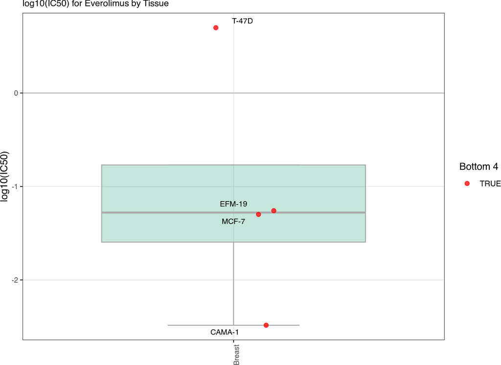

###### 5.3.4.1.1.2 Giredestrant

🔍 Zoom In for Details

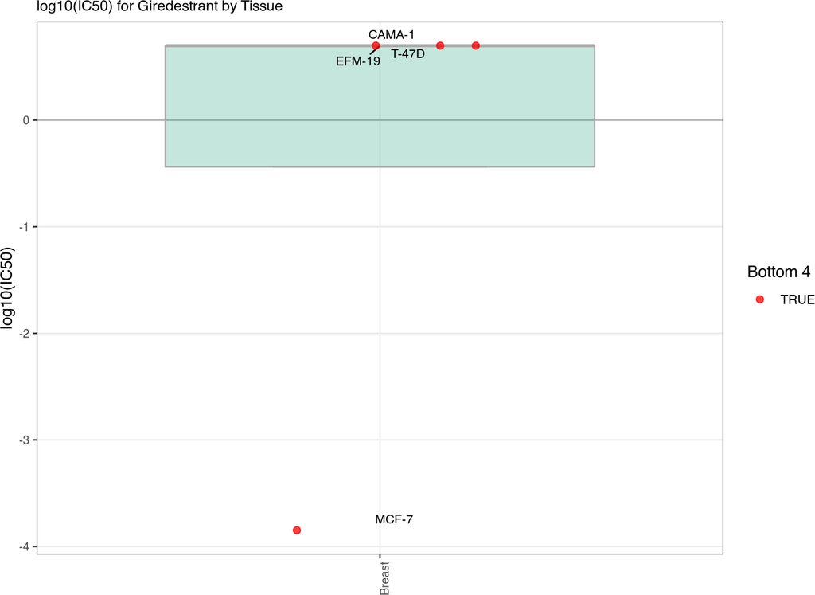

###### 5.3.4.1.1.3 Inavolisib

🔍 Zoom In for Details

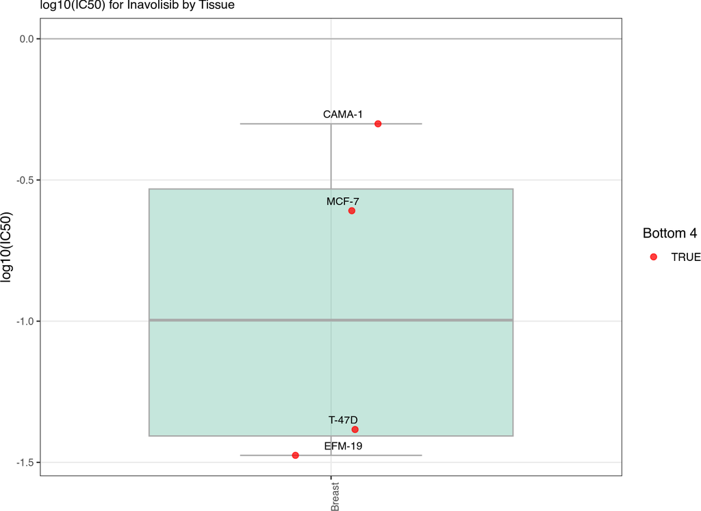

##### 5.3.4.1.2 E Max

###### 5.3.4.1.2.1 Everolimus

🔍 Zoom In for Details

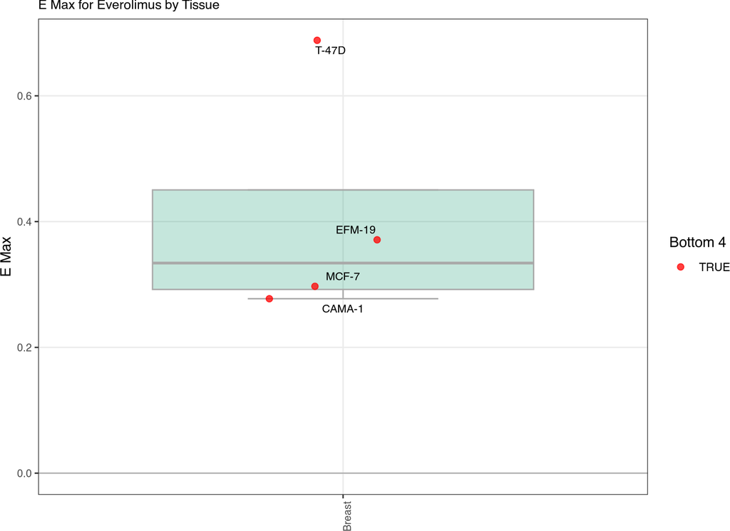

###### 5.3.4.1.2.2 Giredestrant

🔍 Zoom In for Details

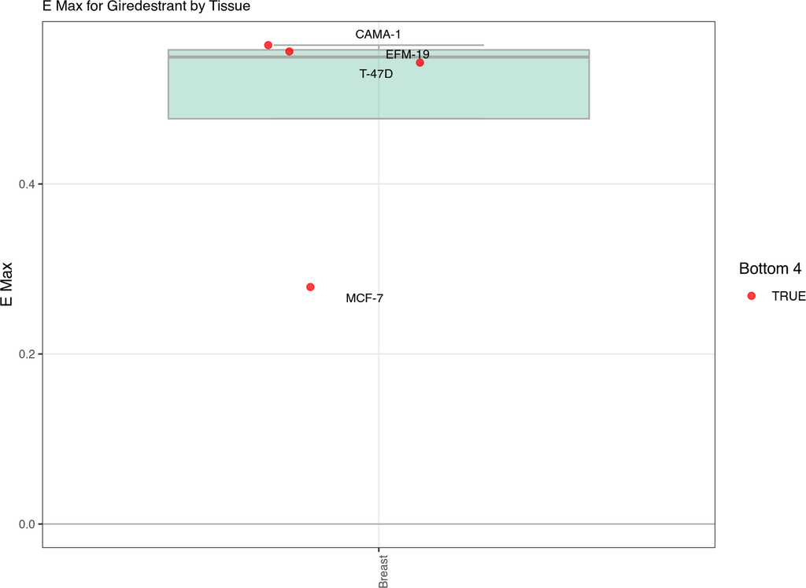

###### 5.3.4.1.2.3 Inavolisib

🔍 Zoom In for Details

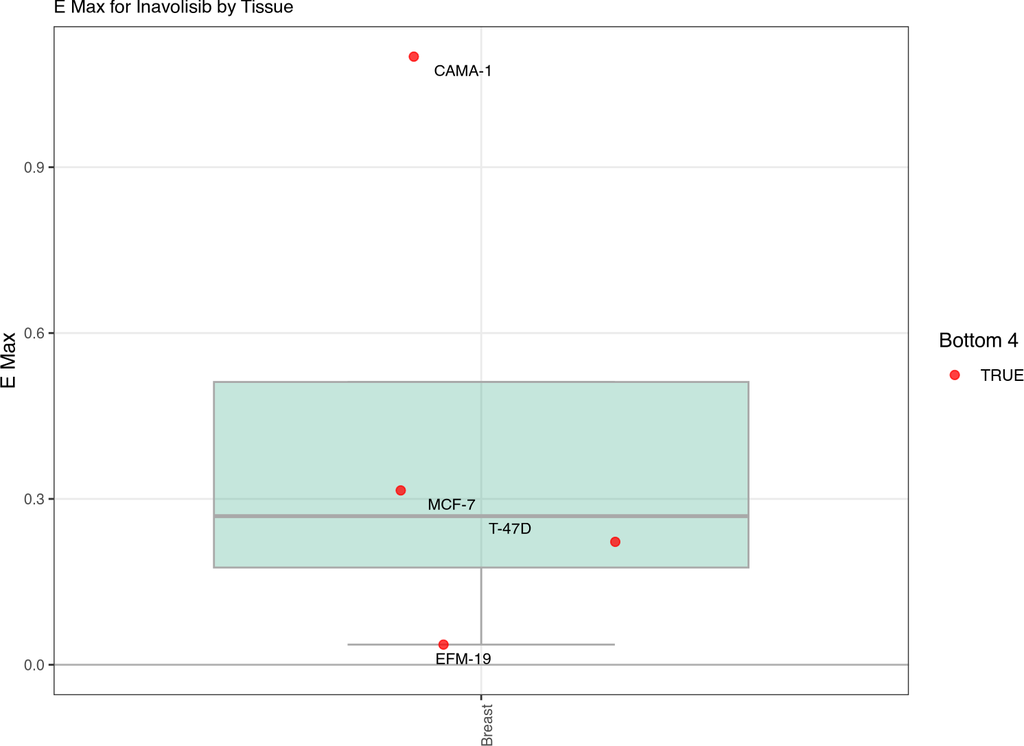

##### 5.3.4.1.3 RV Mean

###### 5.3.4.1.3.1 Everolimus

🔍 Zoom In for Details

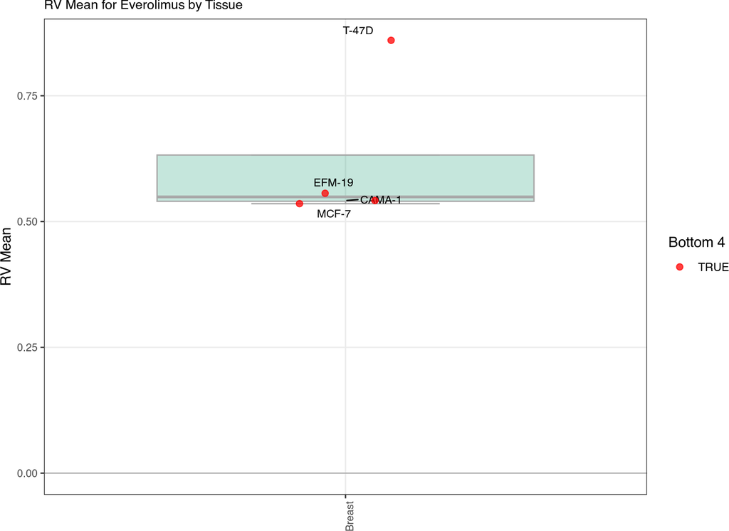

###### 5.3.4.1.3.2 Giredestrant

🔍 Zoom In for Details

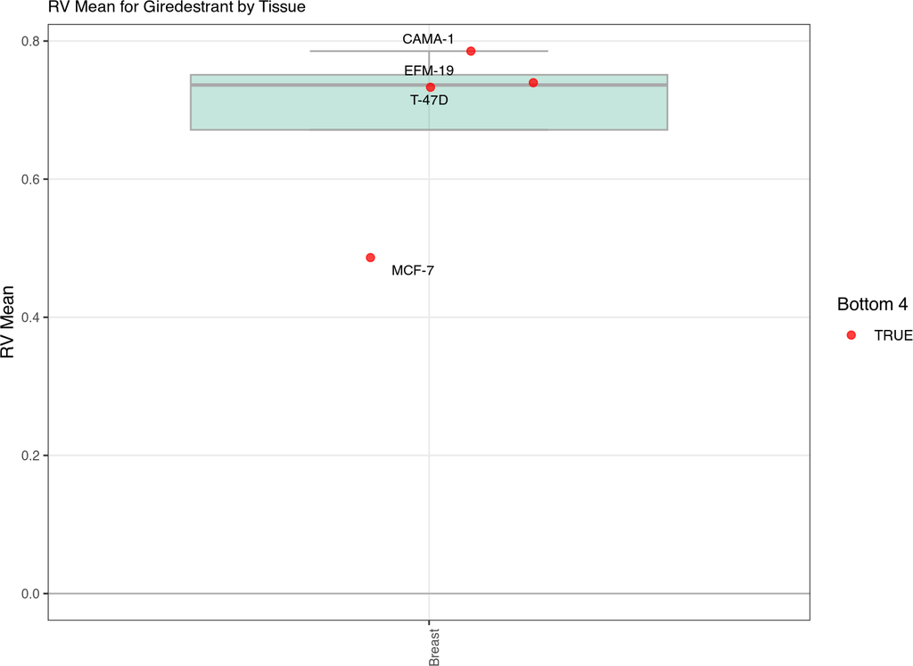

###### 5.3.4.1.3.3 Inavolisib

🔍 Zoom In for Details

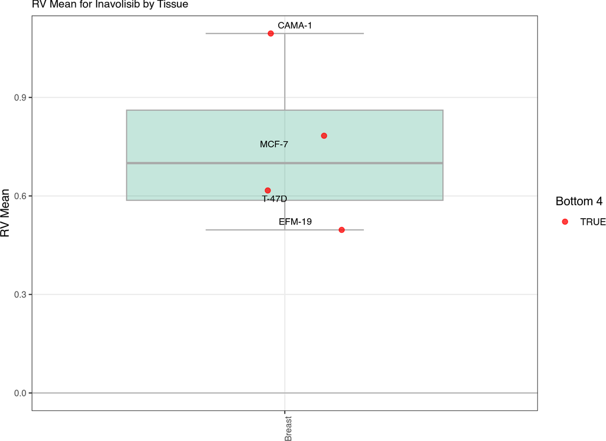

##### 5.3.4.1.4 RV AOC

###### 5.3.4.1.4.1 Everolimus

🔍 Zoom In for Details

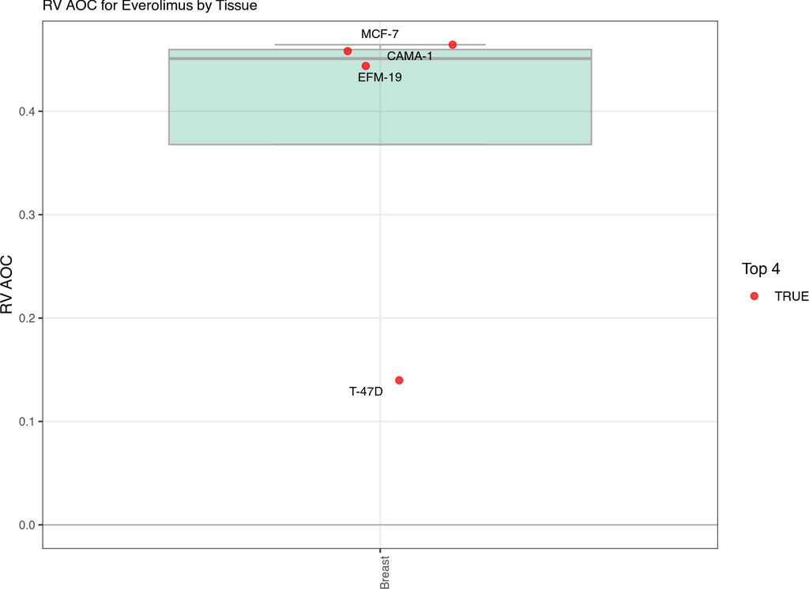

###### 5.3.4.1.4.2 Giredestrant

🔍 Zoom In for Details

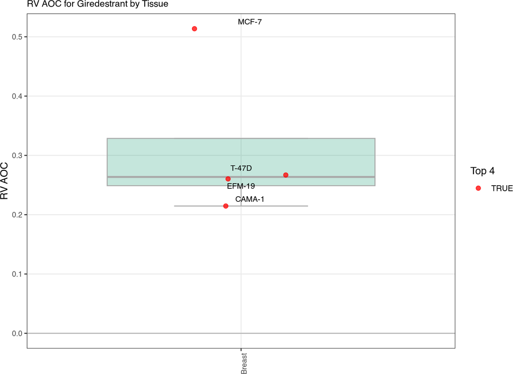

###### 5.3.4.1.4.3 Inavolisib

🔍 Zoom In for Details

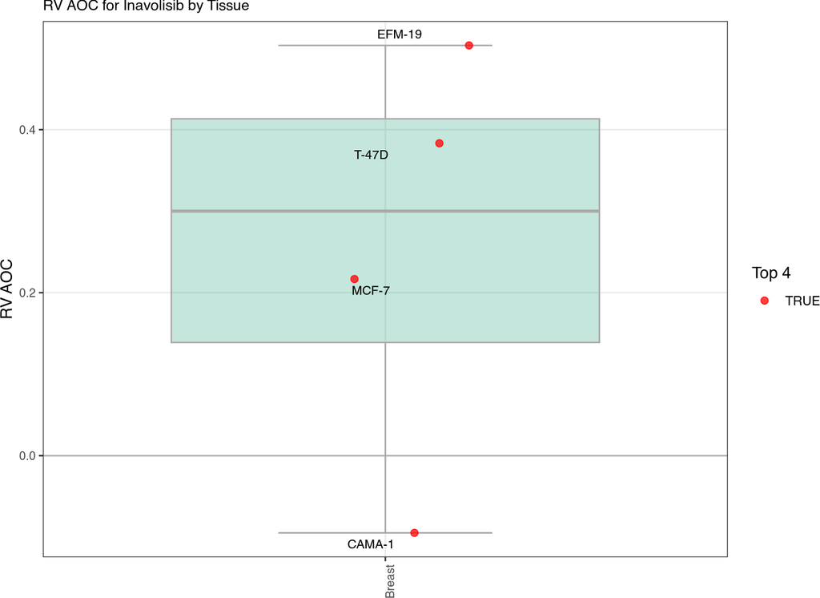

##### 5.3.4.1.5 RV AOC within set range

###### 5.3.4.1.5.1 Everolimus

🔍 Zoom In for Details

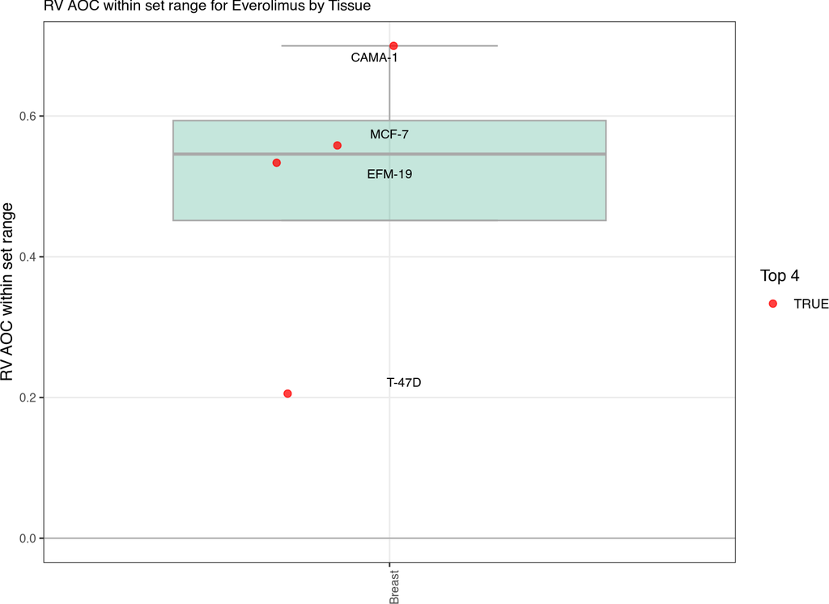

###### 5.3.4.1.5.2 Giredestrant

🔍 Zoom In for Details

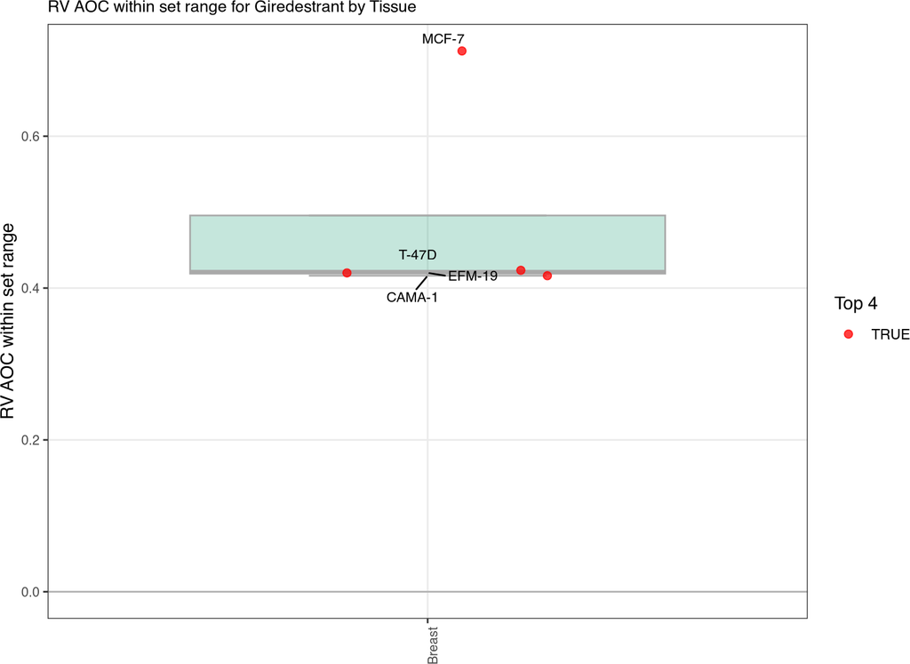

###### 5.3.4.1.5.3 Inavolisib

🔍 Zoom In for Details

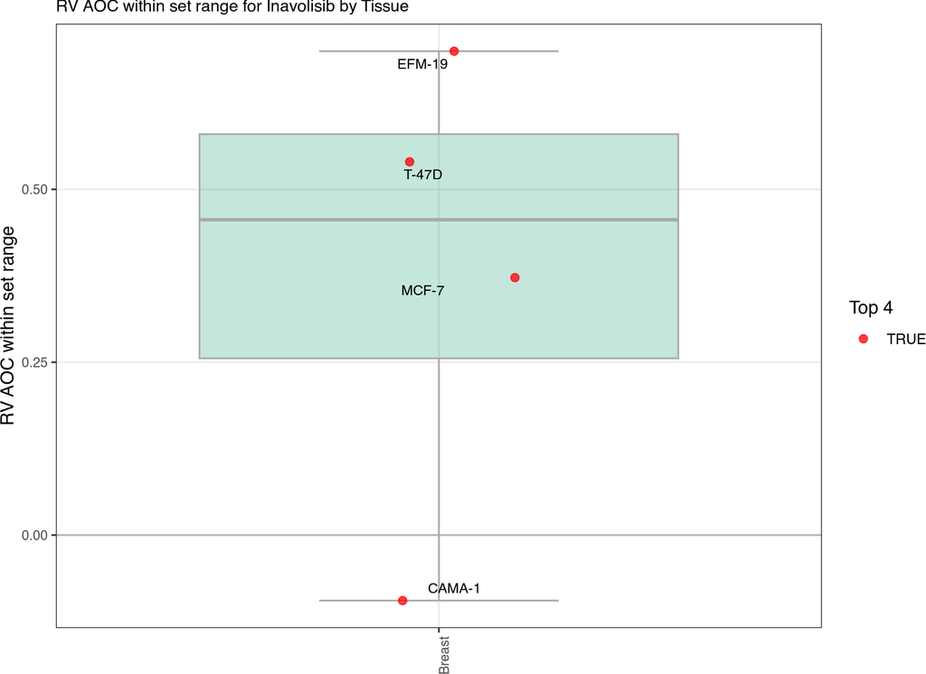

#### 5.3.4.2 GR Value

##### 5.3.4.2.1 log10(GR50)

###### 5.3.4.2.1.1 Everolimus

🔍 Zoom In for Details

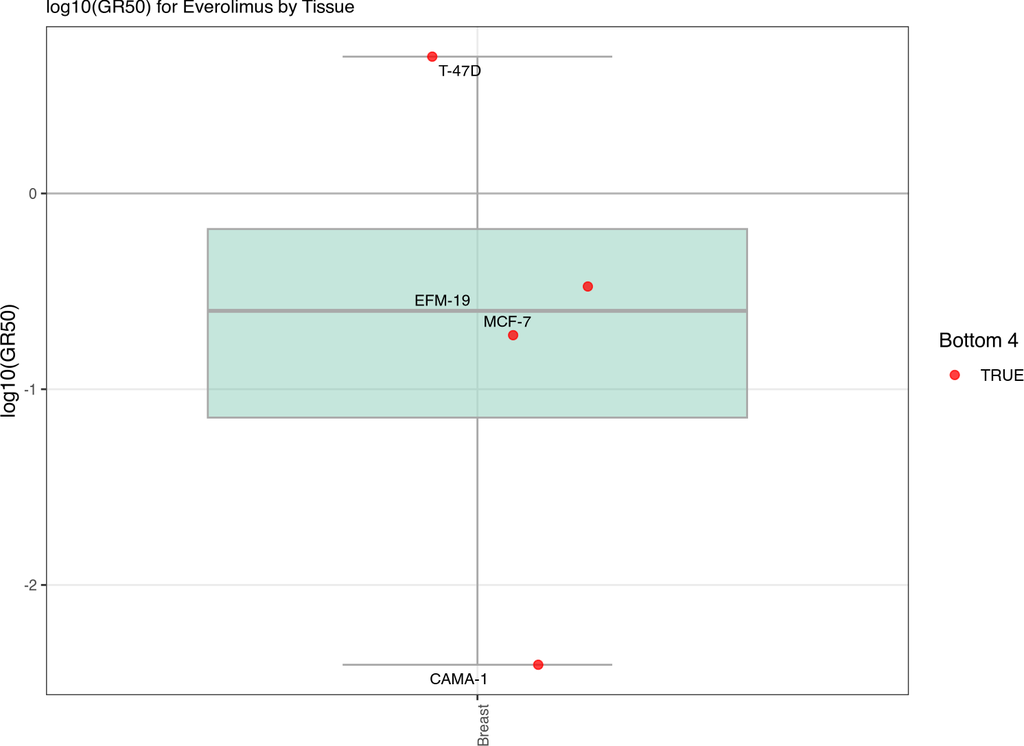

###### 5.3.4.2.1.2 Giredestrant

🔍 Zoom In for Details

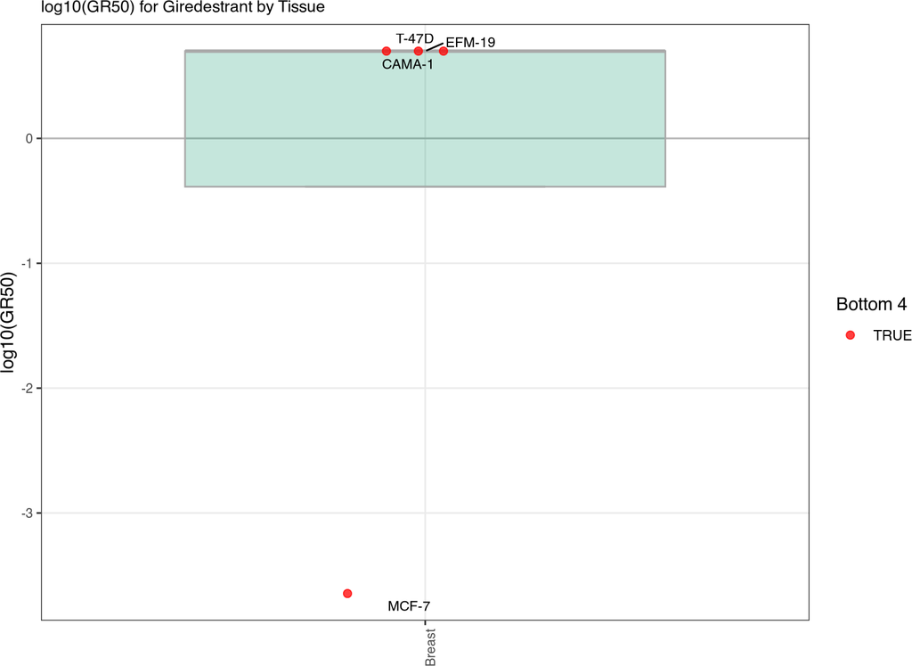

###### 5.3.4.2.1.3 Inavolisib

🔍 Zoom In for Details

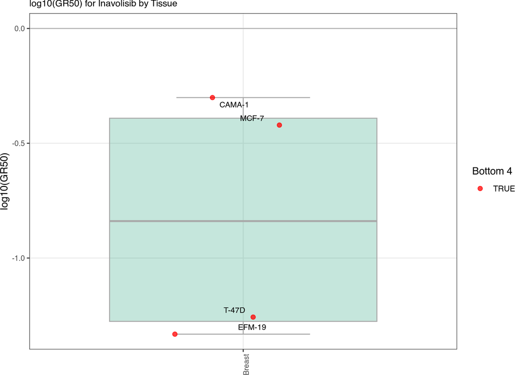

##### 5.3.4.2.2 GR Max

###### 5.3.4.2.2.1 Everolimus

🔍 Zoom In for Details

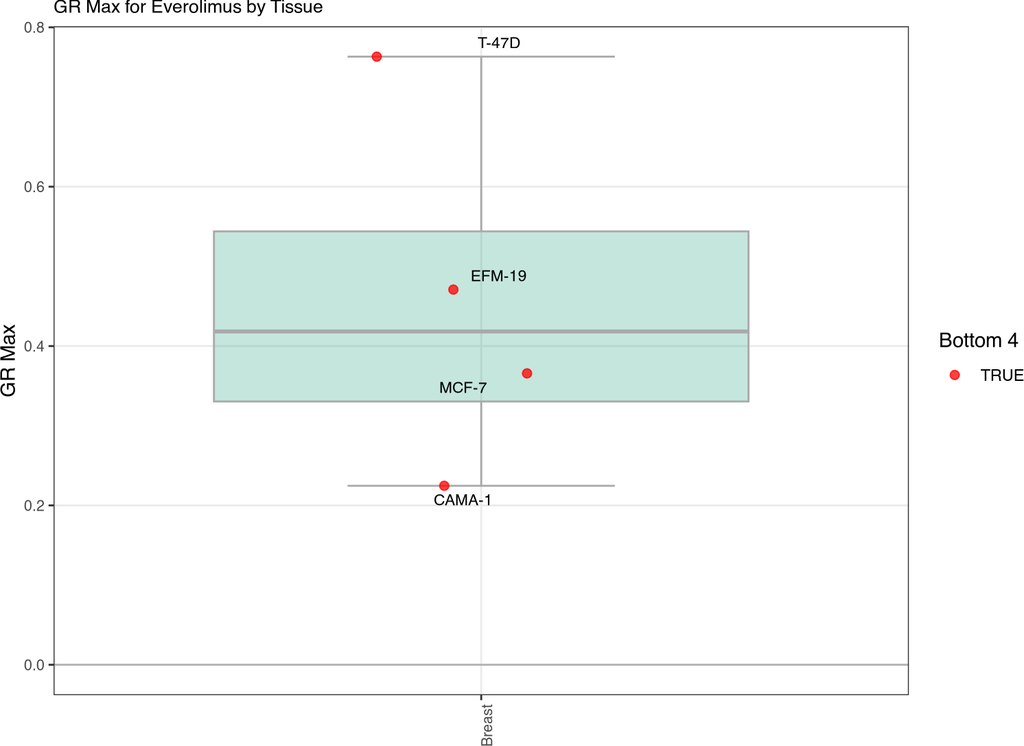

###### 5.3.4.2.2.2 Giredestrant

🔍 Zoom In for Details

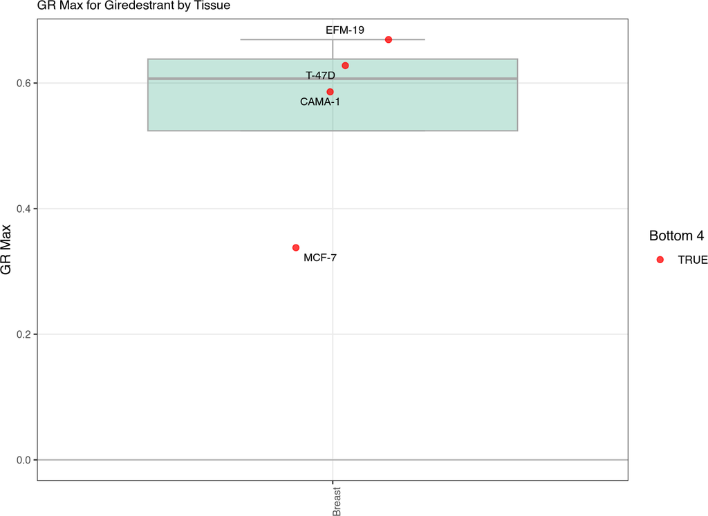

###### 5.3.4.2.2.3 Inavolisib

🔍 Zoom In for Details

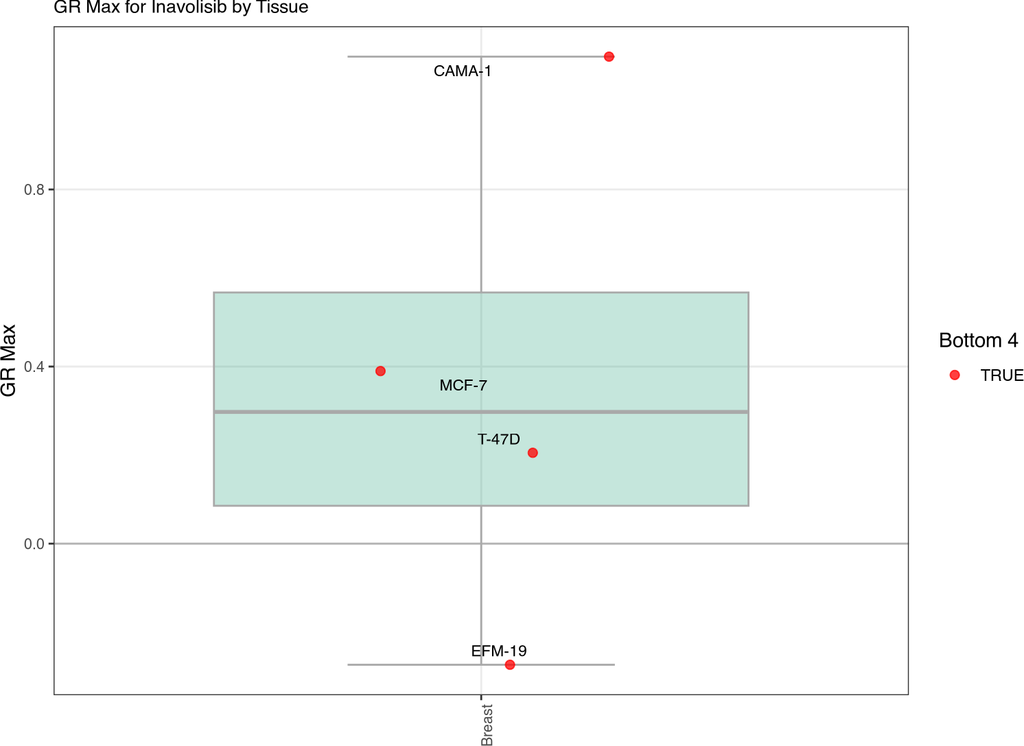

##### 5.3.4.2.3 GR Mean

###### 5.3.4.2.3.1 Everolimus

🔍 Zoom In for Details

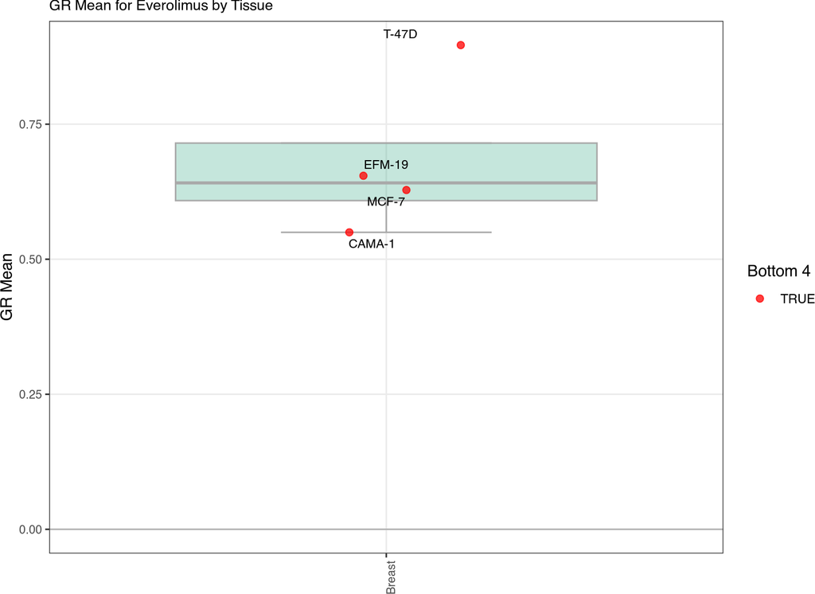

###### 5.3.4.2.3.2 Giredestrant

🔍 Zoom In for Details

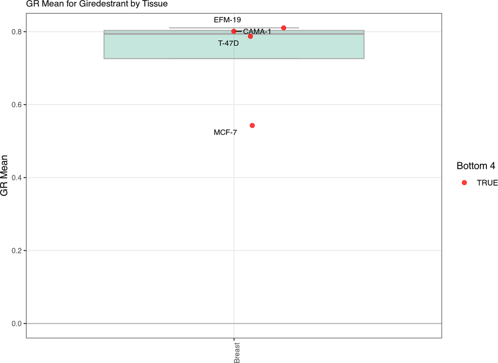

###### 5.3.4.2.3.3 Inavolisib

🔍 Zoom In for Details

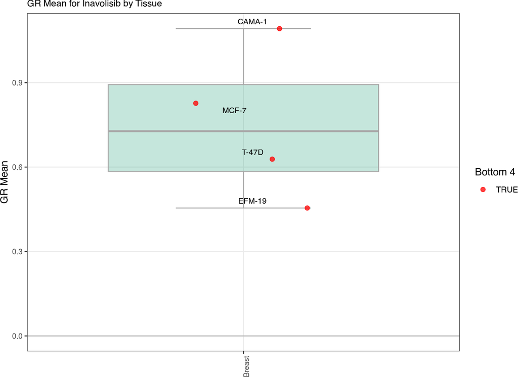

##### 5.3.4.2.4 GR AOC

###### 5.3.4.2.4.1 Everolimus

🔍 Zoom In for Details

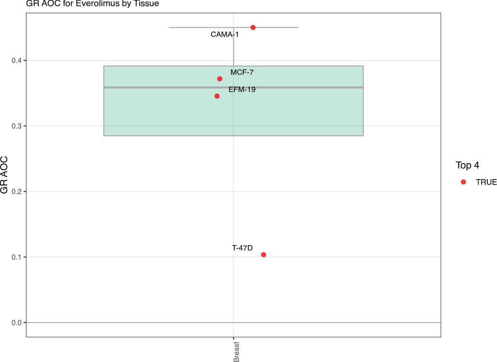

###### 5.3.4.2.4.2 Giredestrant

🔍 Zoom In for Details

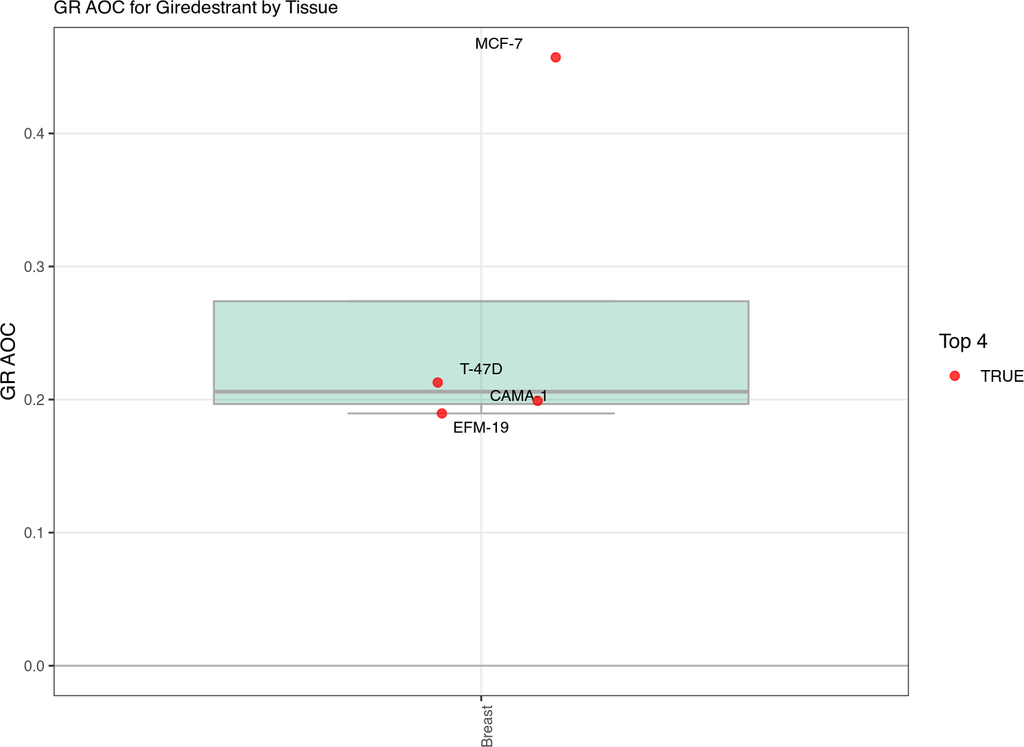

###### 5.3.4.2.4.3 Inavolisib

🔍 Zoom In for Details

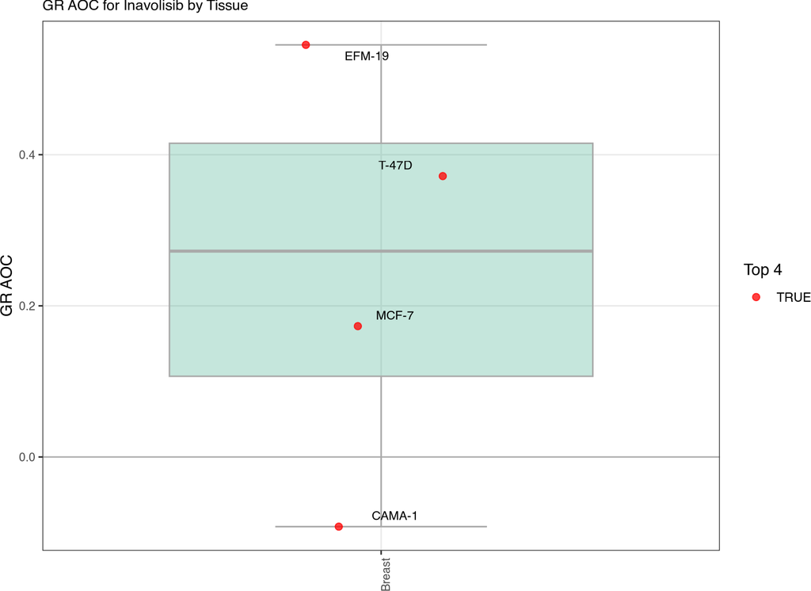

##### 5.3.4.2.5 GR AOC within set range

###### 5.3.4.2.5.1 Everolimus

🔍 Zoom In for Details

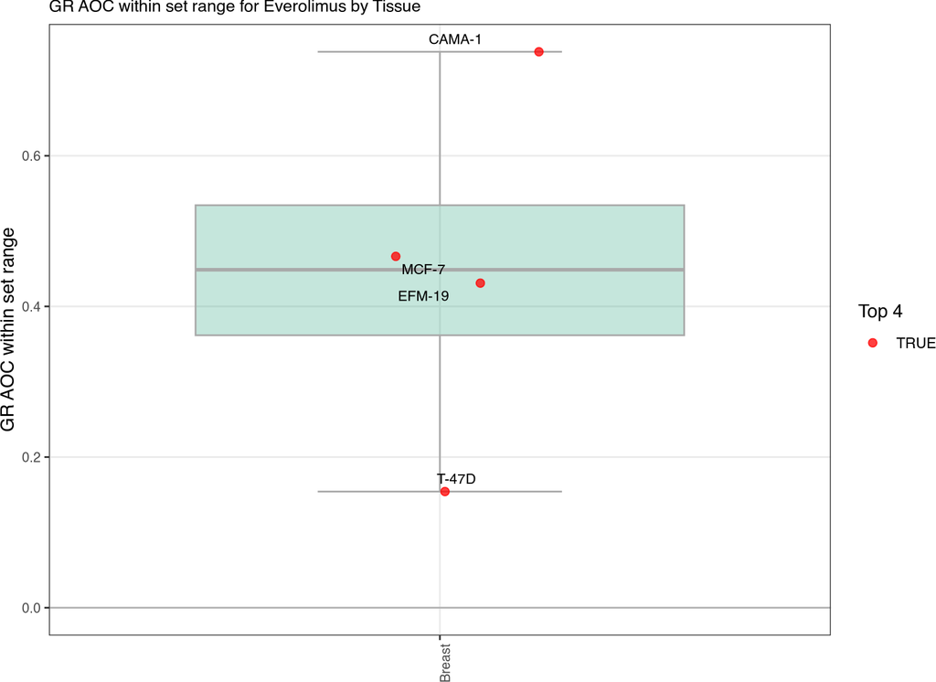

###### 5.3.4.2.5.2 Giredestrant

🔍 Zoom In for Details

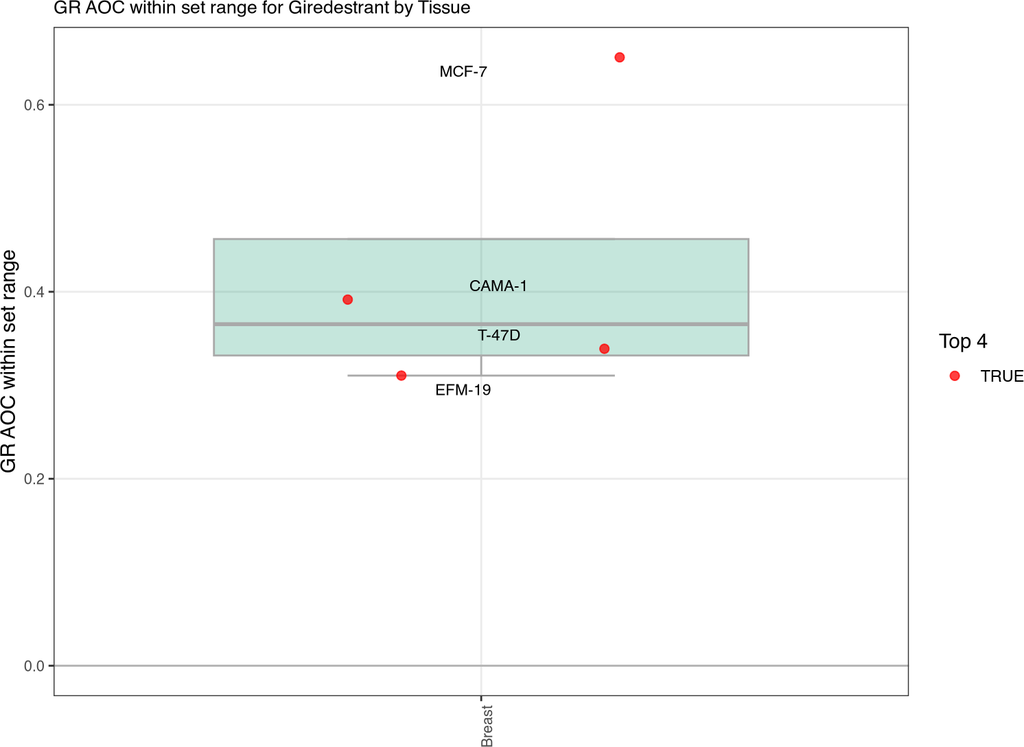

###### 5.3.4.2.5.3 Inavolisib

🔍 Zoom In for Details

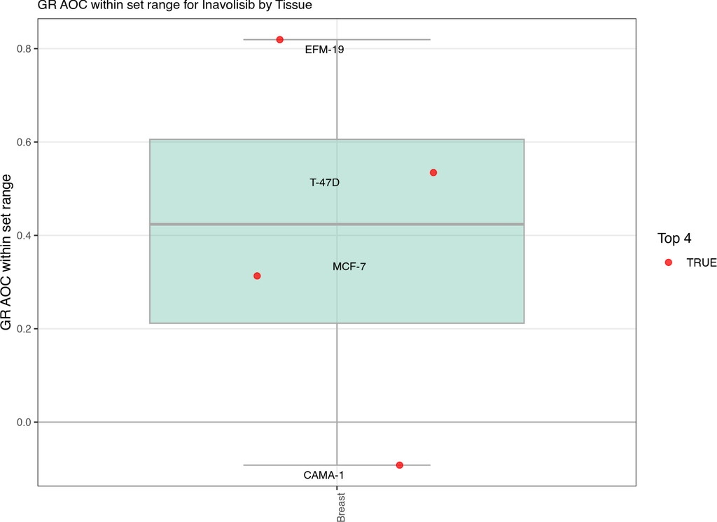

## 5.4 Data Analysis - Dose-response Curves by Cell Lines - Combination Data

These plots show the dose-response surface for each drug combination within a given cell line. Each small panel shows the dose-response curve for the first drug at a fixed concentration of the second drug.

**What to look for:** Look for shifts in the curves of Drug 1 in the presence of increasing concentrations of Drug 2 (and vice versa). A leftward shift or a lower plateau indicates an enhanced effect from the combination.

## 5.5 Data Analysis - Dose-response Curves by Cell Lines - Combination Data

```r
if (TRUE) {
  cellline_name_vec <- sort(unique(response_data_combo[["CellLineName"]]))

  ls_curv_RV <- pmap(list(cl_name = cellline_name_vec),
                     plot_dose_response_combo_panel,
                     dt_average = response_data_combo,
                     normalization_type = "RV")
  names(ls_curv_RV) <- vapply(cellline_name_vec, function(i) escape_special_characters(i),
                              FUN.VALUE = character(1), USE.NAMES = FALSE)
} else {
  tab_grid <-
    unique(response_data_combo[, .SD, .SDcols = c("DrugName", "DrugName_2")])
  setorder(tab_grid)

  ls_names <- sprintf("%s x %s", tab_grid$DrugName, tab_grid$DrugName_2)
  ls_names <- vapply(ls_names, function(i) escape_special_characters(i),
                     FUN.VALUE = character(1), USE.NAMES = FALSE)

  ls_heat_d_RV <- lapply(seq_len(NROW(tab_grid)), function(i) {
    pheatmap_qc(dt_average =
                  response_data_combo[DrugName == tab_grid[i, ]$DrugName &
                                        DrugName_2 == tab_grid[i, ]$DrugName_2],
                normalization_type = "RV",
                lbl_by_CellLineName = TRUE,
                lbl_by_DrugName = TRUE,
                cluster_rows = TRUE)
  })
  names(ls_heat_d_RV) <- ls_names
}
```

```r
if (TRUE) {
  cellline_name_vec <- sort(unique(response_data_combo[["CellLineName"]]))

  ls_curv_GR <- pmap(list(cl_name = cellline_name_vec),
                     plot_dose_response_combo_panel,
                     dt_average = response_data_combo,
                     normalization_type = "GR")
  names(ls_curv_GR) <- vapply(cellline_name_vec, function(i) escape_special_characters(i),
                              FUN.VALUE = character(1), USE.NAMES = FALSE)
} else {
  tab_grid <-
    unique(response_data_combo[, .SD, .SDcols = c("DrugName", "DrugName_2")])
  setorder(tab_grid)

  ls_names <- sprintf("%s x %s", tab_grid$DrugName, tab_grid$DrugName_2)
  ls_names <- vapply(ls_names, function(i) escape_special_characters(i),
                     FUN.VALUE = character(1), USE.NAMES = FALSE)

  ls_heat_d_GR <- lapply(seq_len(NROW(tab_grid)), function(i) {
    pheatmap_qc(dt_average =
                  response_data_combo[DrugName == tab_grid[i, ]$DrugName &
                                        DrugName_2 == tab_grid[i, ]$DrugName_2],
                normalization_type = "GR",
                lbl_by_CellLineName = TRUE,
                lbl_by_DrugName = TRUE,
                cluster_rows = TRUE)
  })
  names(ls_heat_d_GR) <- ls_names
}
```

### 5.5.1 Relative Viability

#### 5.5.1.1 CAMA-1

🔍 Zoom In for Details

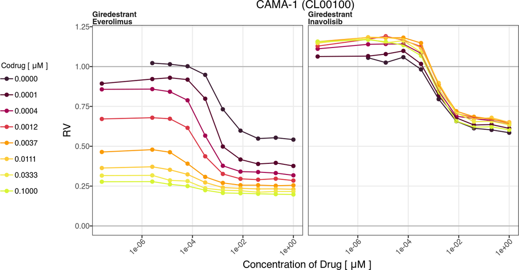

#### 5.5.1.2 EFM-19

🔍 Zoom In for Details

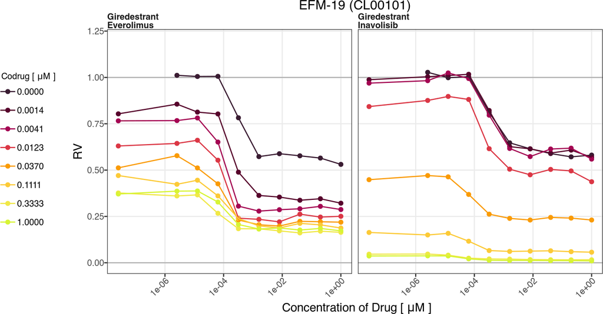

#### 5.5.1.3 MCF-7

🔍 Zoom In for Details

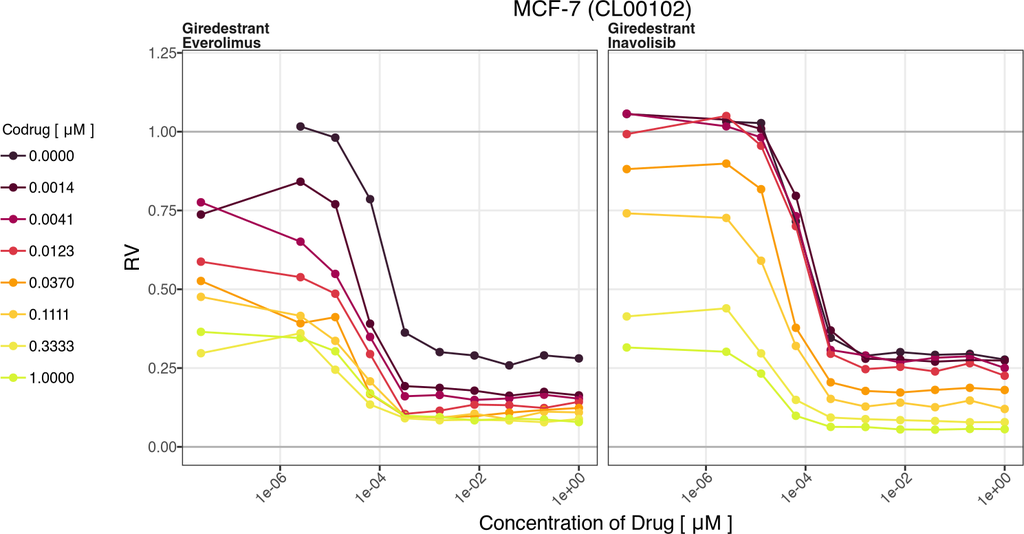

#### 5.5.1.4 T-47D

🔍 Zoom In for Details

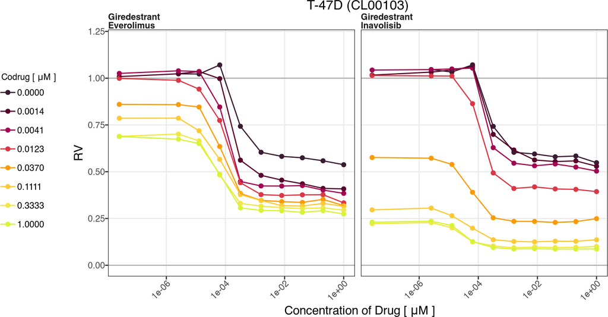